# assignment #5

20141831 박석환

2020 5 20

### Handwritten Digit Recognition

MNIST 데이터셋은 image classification model의 성능을 평가하는 데 주로 활용되는 데이터셋으로, 아래 예와 같이 손으로 쓰여진 숫자들의 이미지 70,000개로 구성되어 있다. 이 중에서 60,000개는 training set으로 활용되며 10,000개는 test set으로 활용된다. 각 데이터는 28 * 28 = 784개의 픽셀의 명암을 0~255 사이의 값으로 표현한 784개의 feature와 0~9 사이의 숫자로 표현되는 target을 포함한다. 본 과제에서는 tree를 활용하여 숫자를 분류하기 위한 classification model을 만들어본다.

#### 1. 아래의 순서에 따라 data preprocessing을 진행하자.

**A. dslabs 패키지를 설치하고, 다음 코드를 실행하면 mnist 변수에 아래 설명과 같이 데이터가 저장된다.**

**B. Training set의 데이터 사이즈가 매우 크기 때문에 60,000개의 데이터 중에 처음 2,000개만 사용하자. 이때 feature 데이터는 변수 train_x에 저장하고, target 데이터는 변수 train_y에 저장한다. train_y의 분포를 확인해 보자.**

**C. train_x의 column의 이름을 V1, V2, V3 … 순서대로 설정하자. colnames() 함수를 사용한다. D. 784개의 픽셀 중에서 숫자와 관련없는 가장자리 부분과 같은 경우는 많은 데이터들에 대해서 같은 색을 가진다. 이러 한 픽셀은 숫자를 분류하는 데 크게 향을 미치지 않으므로 feature에서 제외시키는 것이 합리적이다. caret 패키 지의 nearZeroVar(train_x) 함수를 실행하면 train_x의 column들 중에서 variance가 0이거나 0에 가까운 것들 의 index를 얻을 수 있다. 이 index에 해당하는 column을 train_x에서 제외시키자. 784개의 feature 중에서 몇 개가 제외되었는가?**

**E. 최종적으로 train_x와 train_y를 합쳐서 train이라는 이름의 데이터프레임을 만들자.**

**F. C~E의 과정을 test set에 대해서 동일하게 수행하여 test라는 이름의 데이터프레임을 만들자. 이때 D에서 제외한 feature와 동일한 feature들을 test set에서도 제외시켜야 한다.**

```r
# A - 패키지 데이터를 mnist에 저장
mnist <- dslabs::read_mnist()

# B - 처음 2000개 데이터로 train set의 feature와 target 변수 저장
train_x <- mnist$train$images[1:2000,]
train_x <- as.data.frame(train_x)

train_y <- mnist$train$labels[1:2000]

# C - column 이름 설정
a <- paste0("V",1:784)
colnames(train_x[1:2000,]) <- c(a)

# D - nearZeroVar 함수로 크게 영향을 미치지 않는 feature 제거
library(caret)
train_x1 <- train_x[,-nearZeroVar(train_x)]

# E - feature와 target 합쳐서 train 데이터프레임 생성
train <- cbind(train_x1, target=train_y)

# F - test set에 대해 반복
test_x <- mnist$test$images
test_x <- as.data.frame(test_x)

test_y <- mnist$test$labels

colnames(test_x[1:10000,]) <- c(a)

test_x <- test_x[,-nearZeroVar(train_x)]

test <- cbind(test_x, target=test_y)
```

#### 2. 아래의 코드는 test set의 첫번째 데이터를 화면에 이미지로 출력해준다. 이를 활용하여 test set의 image 행렬의 행 번호를 입력받아 숫자 이미지를 출력하는 함수 print_image()를 만들어보자. 이 함수를 활용하여9, 19, 42번째 숫자를 이미지로 출력해보고 실제 label 값과 비교해보자.

```r
# print_image1 함수 생성 -> train set
print_image1 <-function(x) {
  return (image(1:28, 1:28, matrix(mnist$train$images[x,], nrow=28)[, 28:1], col = gray(seq(0,1,0.05)), xlab= "", ylab =""))
}

# print_image 함수 생성 -> test set
print_image<-function(x) {
  return (image(1:28, 1:28, matrix(mnist$test$images[x,], nrow=28)[, 28:1], col = gray(seq(0,1,0.05)), xlab= "", ylab =""))
}


# 실제 label값과 비교
test$target[9]
```

```
## [1] 5
```

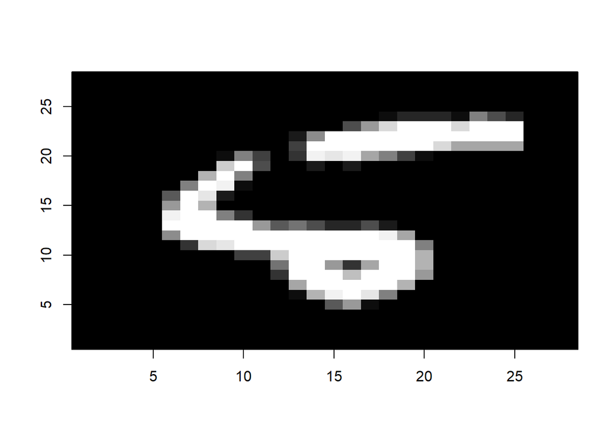

```r
print_image(9)
```

```r
test$target[19]
```

```
## [1] 3
```

[figure not shown]

```r
print_image(19)
```

```r
test$target[42]
```

```
## [1] 7
```

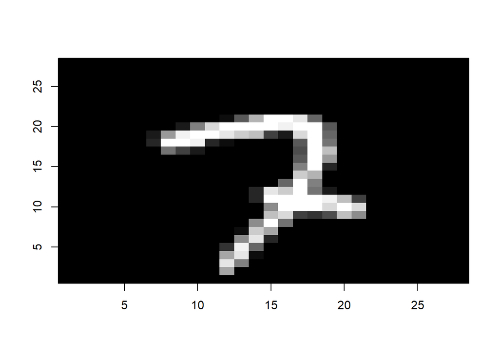

```r
print_image(42)
```

- 3개의 이미지 중 9번째는 애매하지만 19, 42번째는 실제 label 값과 비슷하다.

#### 3. 아래의 순서로 tree를 만들어보자.

**A. Cost complexity parameter 일때, leaf node가 가지는 최소 데이터의 수가 50인 Tree를 만들고 시각화해보자. Tree는 몇 개의 leaf node를 가지는가? Tree의 depth는 얼마인가?**

**B. Cost complexity parameter 일때, depth가 최대 3인 Tree를 만들고 시각화해보자. Tree는 몇개의 leaf node를 가지는가? 만들어진 tree가 실제 classification에 활용될 수 있을까?**

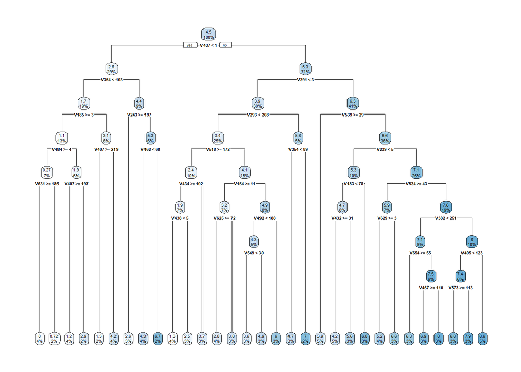

```r
library(rpart)
library(rpart.plot)

# leaf node가 가지는 최소 데이터의 수가 50인 Tree(minbucket=50)
set.seed(123)
ct_tree_1 <- rpart(target~., data=train, method="anova", control = list(minbucket=50,cp=0))
rpart.plot(ct_tree_1)
```

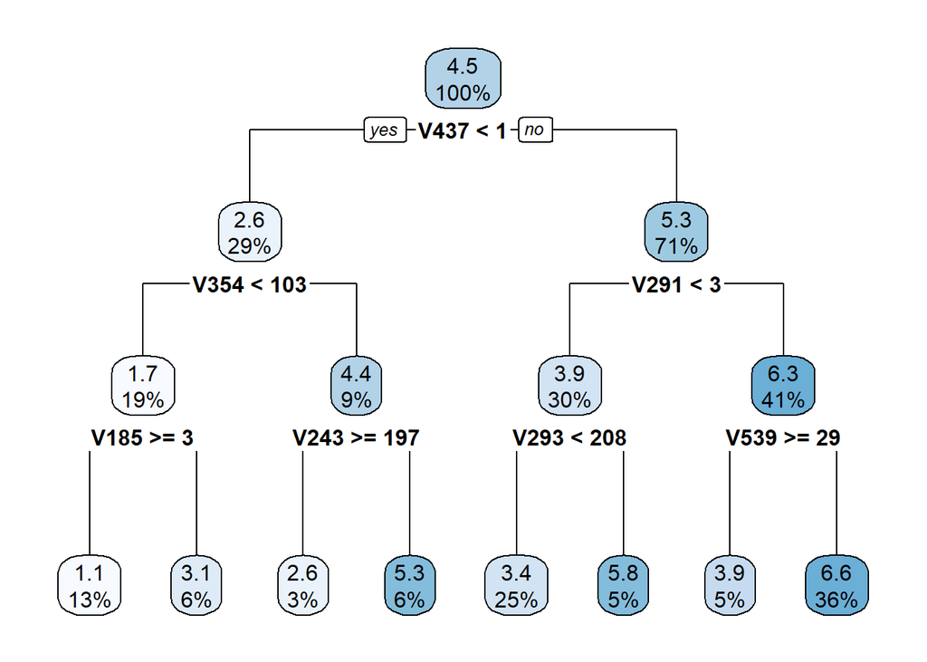

```r
# depth가 최대 3인 Tree(maxdepth=3)
set.seed(123)
ct_tree_2 <- rpart(target~., data=train, method="anova", control = list(maxdepth=3,cp=0))
rpart.plot(ct_tree_2)
```

**A. Cost complexity parameter 일때, leaf node가 가지는 최소 데이터의 수가 50인 Tree를 만들고 시각화해보자. Tree는 몇 개의 leaf node를 가지는가? Tree의 depth는 얼마인가?**

- Tree의 depth는 8이다.

**B. Cost complexity parameter 일때, depth가 최대 3인 Tree를 만들고 시각화해보자. Tree는 몇개의 leaf node를 가지는가? 만들어진 tree가 실제 classification에 활용될 수 있을까?**

- leaf node는 총 8개이다.
- regression tree이기 때문에 결과가 소수로 나왔다. classification을 하기에는 어려움이 있다.

#### 4. Tree Pruning을 수행해보자

**A. rpart() 함수의 다른 control 옵션은 모두 default 값을 사용하고, cp = 0일때의 Tree를 만들자 (시각화는 하지말자. leaf node가 너무 많아 불가능하다.)**

**B. plotcp() 함수를 이용하여 cp값의 변화에 따른 tree의 CV 예측오차를 그래프로 확인하고, CV 예측오차를 가장작게 만드는 cp값을 찾자. 이때 tree의 leaf node 수는 몇인가?**

**C. 찾은 cp값을 이용하여 prunned tree를 만들자.**

**D. prunned tree model로 test set에 대한 예측을 수행하고, confusion matrix를 계산해보자. Test set에 대한 예측 정확도는 얼마인가?**

```r
# control option이 모두 default값이고, cp=0 인 Tree 생성
set.seed(123)
tree_default <- rpart(target~., data=train, method="anova", control = list(cp=0))

# cp값에 따른 tree특징 출력
printcp(tree_default)
```

```
##
## Regression tree:
## rpart(formula = target ~ ., data = train, method = "anova", control = list(cp = 0))
##
## Variables actually used in tree construction:
##   [1] V154 V155 V156 V159 V179 V180 V181 V182 V183 V184 V185 V186 V206 V211 V214
##  [16] V216 V217 V234 V235 V236 V238 V239 V240 V241 V243 V246 V262 V263 V266 V267
##  [31] V270 V271 V273 V289 V291 V293 V295 V296 V297 V300 V301 V317 V319 V324 V326
##  [46] V327 V346 V347 V351 V352 V354 V356 V373 V376 V379 V380 V382 V384 V401 V402
##  [61] V405 V407 V408 V412 V431 V432 V434 V435 V437 V438 V456 V457 V459 V461 V462
##  [76] V464 V467 V469 V484 V487 V488 V491 V492 V497 V514 V517 V518 V519 V521 V522
##  [91] V523 V524 V539 V542 V543 V569 V571 V572 V573 V605 V607 V630 V631 V654
##
## Root node error: 16538/2000 = 8.2689
##
```

[output cut: 124 more lines]

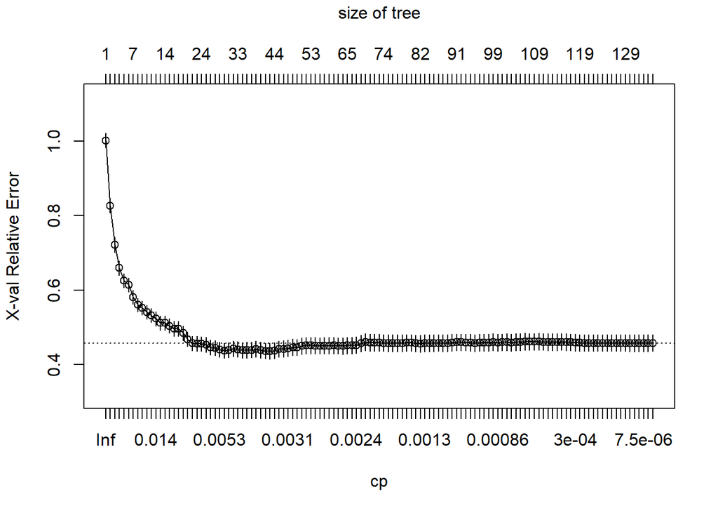

```r
# cv예측오차 그래프
plotcp(tree_default)
```

```r
# cv예측오차를 가장 작게 만드는 cp값 생성
best_cp <- tree_default$cptable[which.min(tree_default$cptable[,"xerror"]), "CP"]
best_cp
```

```
## [1] 0.003751902
```

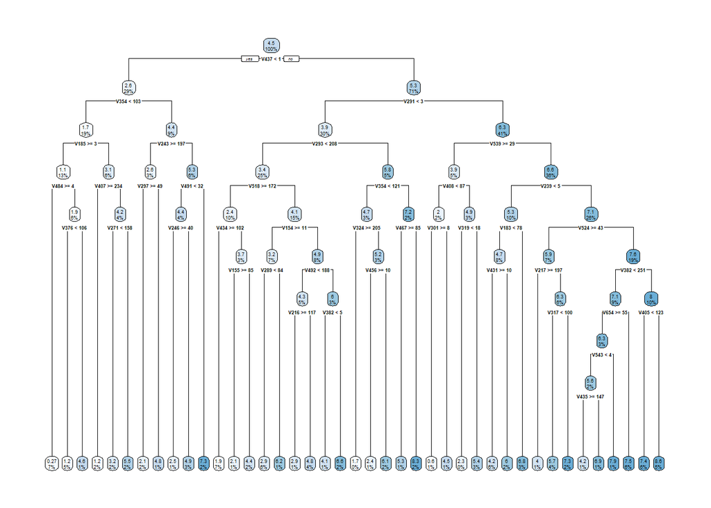

```r
# 찾은 cp값으로 prunned tree 생성
set.seed(123)
best_tree <- prune(tree_default, cp = best_cp)

rpart.plot(best_tree)
```

```r
# predict함수를 사용해 test set에 대한 예측 수행
pred_pr_tree <- predict(best_tree, newdata = test)
pred_class <- factor(round(pred_pr_tree), levels=0:9)

#confusionMatrix 사용
confusionMatrix(pred_class, factor(test$target))
```

```
## Confusion Matrix and Statistics
##
##           Reference
## Prediction   0   1   2   3   4   5   6   7   8   9
##          0 644   0  66   3   1   7  12   0   5   9
##          1  90 539 102  27  10  48  13   9  10   5
##          2  24 412 461 142  30  20  37  51  71  12
##          3  56 120 178 453  66  48  34  20  24   8
##          4   5  16  52  23 471 133 183  94  56  31
##          5 100  13  65 217 104 342 212  60 119  64
##          6  40  20  35  63  73 141 279 104  97  20
##          7  12   5  62  68 113 112 168 475 339 371
##          8   9  10  11  11  77  40  17 213 177 205
##          9   0   0   0   3  37   1   3   2  76 284
##
## Overall Statistics
##
##                Accuracy : 0.4125
##                  95% CI : (0.4028, 0.4222)
##     No Information Rate : 0.1135
##     P-Value [Acc > NIR] : < 2.2e-16
##
##                   Kappa : 0.3473
##
##  Mcnemar's Test P-Value : < 2.2e-16
##
## Statistics by Class:
##
##                      Class: 0 Class: 1 Class: 2 Class: 3 Class: 4 Class: 5
## Sensitivity            0.6571   0.4749   0.4467   0.4485   0.4796   0.3834
## Specificity            0.9886   0.9646   0.9109   0.9384   0.9342   0.8953
## Pos Pred Value         0.8621   0.6319   0.3659   0.4499   0.4427   0.2639
## Neg Pred Value         0.9637   0.9348   0.9347   0.9381   0.9428   0.9368
## Prevalence             0.0980   0.1135   0.1032   0.1010   0.0982   0.0892
## Detection Rate         0.0644   0.0539   0.0461   0.0453   0.0471   0.0342
## Detection Prevalence   0.0747   0.0853   0.1260   0.1007   0.1064   0.1296
## Balanced Accuracy      0.8229   0.7197   0.6788   0.6934   0.7069   0.6393
##                      Class: 6 Class: 7 Class: 8 Class: 9
## Sensitivity            0.2912   0.4621   0.1817   0.2815
## Specificity            0.9344   0.8607   0.9343   0.9864
## Pos Pred Value         0.3200   0.2754   0.2299   0.6995
## Neg Pred Value         0.9256   0.9332   0.9137   0.9244
## Prevalence             0.0958   0.1028   0.0974   0.1009
## Detection Rate         0.0279   0.0475   0.0177   0.0284
## Detection Prevalence   0.0872   0.1725   0.0770   0.0406
## Balanced Accuracy      0.6128   0.6614   0.5580   0.6339
```

**B. plotcp() 함수를 이용하여 cp값의 변화에 따른 tree의 CV 예측오차를 그래프로 확인하고, CV 예측오차를 가장작게 만드는 cp값을 찾자. 이때 tree의 leaf node 수는 몇인가?**

- cv 예측오차를 가장 작게 만드는 cp : 0.003751902
- 그래프를 확인해보면 best cp에서 leaf node는 41개이다.

**D. prunned tree model로 test set에 대한 예측을 수행하고, confusion matrix를 계산해보자. Test set에 대한 예측 정확도는 얼마인가?**

- Accuracy : 0.4125 -> 41.25%

#### 5. Random Forest를 만들어보자

**A. randomForest() 함수를 사용하여 bagging model을 만들어보자. mtry를 제외한 옵션은 모두 default 값을 사용한다. plot() 함수를 사용하여 Bagging model에서 tree의 수의 증가에 따른 OOB classification error rate의 변화를 그래프로 출력해보자. 어떤 경향을 보이는가?**

**B. Bagging model로 test set에 대한 예측을 수행하고, confusion matrix를 계산해보자. Test set에 대한 예측정확도는 얼마인가? 4번에서 계산한 prunned tree model에 비해서 성능이 얼마나 향상되었는가?**

**C. randomForest() 함수의 default 옵션을 사용하여 random forest model을 만들어보자. 그리고 Bagging과 random forest 모델의 Tree의 수의 증가에 따른 OOB classification error rate의 변화를 하나의 그래프에 그려보고 두 모델의 성능을 비교해보자.**

**D. Random forest model로 test set에 대한 예측을 수행하고, confusion matrix를 계산해보자. Test set에 대한 예측 정확도는 얼마인가? Bagging model에 비해서 성능이 얼마나 향상되었는가?**

**E. D번의 confusion matrix 결과로부터, 분류가 가장 정확한 숫자는 몇인가? 가장 분류가 어려운 숫자는 몇인가?**

**F. 실제 값은 7이지만 Random forest model에 의해 1로 예측되는 test data를 찾아 이미지를 몇 개 출력해보자. 눈으로 확인했을 때 7과 1의 구별이 어려운가?**

```r
# Random Forest를 만들기 위해 요인화시켜주기
train$target <- factor(train$target)
str(train$target)
```

```
##  Factor w/ 10 levels "0","1","2","3",..: 6 1 5 2 10 3 2 4 2 5 ...
```

```r
test$target <- factor(test$target)
str(test$target)
```

```
##  Factor w/ 10 levels "0","1","2","3",..: 8 3 2 1 5 2 5 10 6 10 ...
```

```r
# Bagging model 생성
library(randomForest)
```

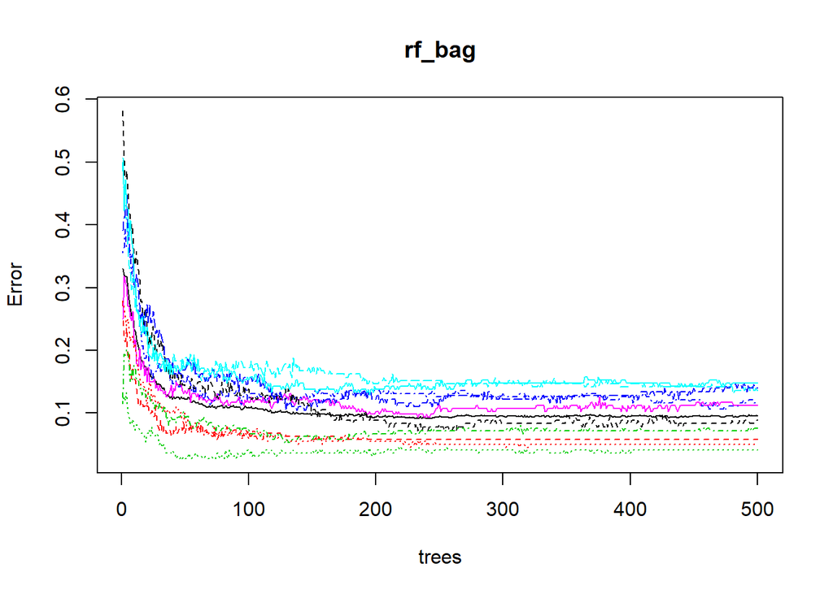

```r
set.seed(123)
rf_bag <- randomForest(target~., data=train, mtry=244)
plot(rf_bag)
```

```r
# predict함수로 예측 수행 및 confusion matrix 생성
pred_class_bag <- predict(rf_bag, newdata=test, type="class")
confusionMatrix(pred_class_bag, test$target)
```

```
## Confusion Matrix and Statistics
##
##           Reference
## Prediction    0    1    2    3    4    5    6    7    8    9
##          0  940    0    9    4    1   17   21    0    7    5
##          1    0 1107    3    0    2    8    3    7    7    4
##          2    0    7  929   27    4    1   24   33   15   10
##          3    3    6    8  832    2   16    0    6   23   15
##          4    3    0   14    2  866   10   25    3   13   27
##          5   10    1   10   84    2  800   17    1   26   16
##          6    9    3   16    5   19   10  858    0   27    8
##          7   11    1   26   28    1   11    2  922    5   12
##          8    2   10   11   17   12   11    7    4  802    3
##          9    2    0    6   11   73    8    1   52   49  909
##
## Overall Statistics
##
##                Accuracy : 0.8965
##                  95% CI : (0.8904, 0.9024)
##     No Information Rate : 0.1135
##     P-Value [Acc > NIR] : < 2.2e-16
##
##                   Kappa : 0.885
##
##  Mcnemar's Test P-Value : NA
##
## Statistics by Class:
##
##                      Class: 0 Class: 1 Class: 2 Class: 3 Class: 4 Class: 5
## Sensitivity            0.9592   0.9753   0.9002   0.8238   0.8819   0.8969
## Specificity            0.9929   0.9962   0.9865   0.9912   0.9892   0.9817
## Pos Pred Value         0.9363   0.9702   0.8848   0.9133   0.8993   0.8273
## Neg Pred Value         0.9956   0.9968   0.9885   0.9804   0.9872   0.9898
## Prevalence             0.0980   0.1135   0.1032   0.1010   0.0982   0.0892
## Detection Rate         0.0940   0.1107   0.0929   0.0832   0.0866   0.0800
## Detection Prevalence   0.1004   0.1141   0.1050   0.0911   0.0963   0.0967
## Balanced Accuracy      0.9760   0.9857   0.9434   0.9075   0.9356   0.9393
##                      Class: 6 Class: 7 Class: 8 Class: 9
## Sensitivity            0.8956   0.8969   0.8234   0.9009
## Specificity            0.9893   0.9892   0.9915   0.9775
## Pos Pred Value         0.8984   0.9048   0.9124   0.8182
## Neg Pred Value         0.9889   0.9882   0.9811   0.9888
## Prevalence             0.0958   0.1028   0.0974   0.1009
## Detection Rate         0.0858   0.0922   0.0802   0.0909
## Detection Prevalence   0.0955   0.1019   0.0879   0.1111
## Balanced Accuracy      0.9424   0.9430   0.9074   0.9392
```

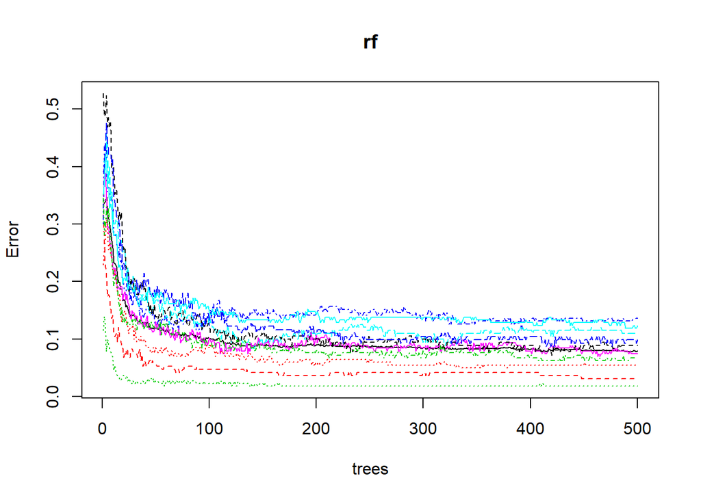

```r
# Random Forest model 생성
set.seed(123)
rf <- randomForest(target~., data=train)
plot(rf)
```

```r
# predict함수로 예측 수행 및 confusion matrix 생성
pred_class_rf <- predict(rf, newdata=test, type="class")
confusionMatrix(pred_class_rf, test$target)
```

```
## Confusion Matrix and Statistics
##
##           Reference
## Prediction    0    1    2    3    4    5    6    7    8    9
##          0  954    0   10    2    1   16   19    0    9    8
##          1    0 1113    1    0    1   10    3   12    3    5
##          2    3    3  949   24    4    1   22   36    8    7
##          3    0    3    7  882    0   20    0    0   19   15
##          4    5    0   14    2  895   10   16    4   12   20
##          5    7    3    6   57    0  790   12    1   19    9
##          6    7    4   15    5   15   14  882    1   22    5
##          7    3    1   17   18    0    9    1  924    9   10
##          8    1    8   11   12    5    6    3    4  833    4
##          9    0    0    2    8   61   16    0   46   40  926
##
## Overall Statistics
##
##                Accuracy : 0.9148
##                  95% CI : (0.9092, 0.9202)
##     No Information Rate : 0.1135
##     P-Value [Acc > NIR] : < 2.2e-16
##
##                   Kappa : 0.9053
##
##  Mcnemar's Test P-Value : NA
##
## Statistics by Class:
##
##                      Class: 0 Class: 1 Class: 2 Class: 3 Class: 4 Class: 5
## Sensitivity            0.9735   0.9806   0.9196   0.8733   0.9114   0.8857
## Specificity            0.9928   0.9961   0.9880   0.9929   0.9908   0.9875
## Pos Pred Value         0.9362   0.9695   0.8978   0.9323   0.9151   0.8739
## Neg Pred Value         0.9971   0.9975   0.9907   0.9859   0.9904   0.9888
## Prevalence             0.0980   0.1135   0.1032   0.1010   0.0982   0.0892
## Detection Rate         0.0954   0.1113   0.0949   0.0882   0.0895   0.0790
## Detection Prevalence   0.1019   0.1148   0.1057   0.0946   0.0978   0.0904
## Balanced Accuracy      0.9831   0.9883   0.9538   0.9331   0.9511   0.9366
##                      Class: 6 Class: 7 Class: 8 Class: 9
## Sensitivity            0.9207   0.8988   0.8552   0.9177
## Specificity            0.9903   0.9924   0.9940   0.9808
## Pos Pred Value         0.9093   0.9315   0.9391   0.8426
## Neg Pred Value         0.9916   0.9885   0.9845   0.9907
## Prevalence             0.0958   0.1028   0.0974   0.1009
## Detection Rate         0.0882   0.0924   0.0833   0.0926
## Detection Prevalence   0.0970   0.0992   0.0887   0.1099
## Balanced Accuracy      0.9555   0.9456   0.9246   0.9492
```

```r
# target이 7이고 예측값이 1인 경우의 data찾기
rf_real_7 <- rf$y==7
str(rf_real_7)
```

```
##  logi [1:2000] FALSE FALSE FALSE FALSE FALSE FALSE ...
```

```r
rf_pre_1 <- rf$predicted==1
rf_real_7[2]
```

```
## [1] FALSE
```

```r
num <- NULL
for (i in 1:2000) {
  if (rf_real_7[i]&&rf_pre_1[i]){
    num <- append(num, i)
  }
}
str(num)
```

```
##  int [1:3] 612 645 885
```

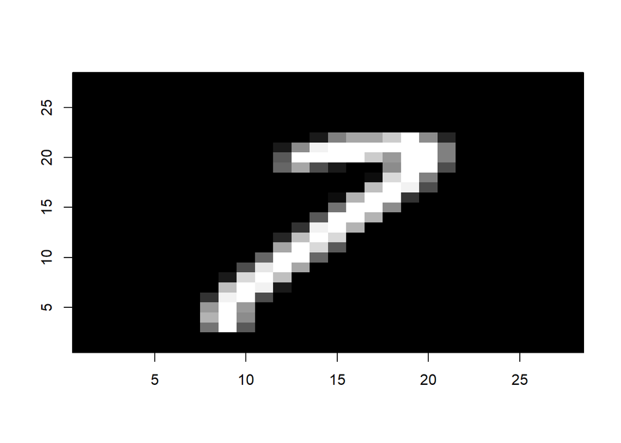

```r
#

print_image1(612)
```

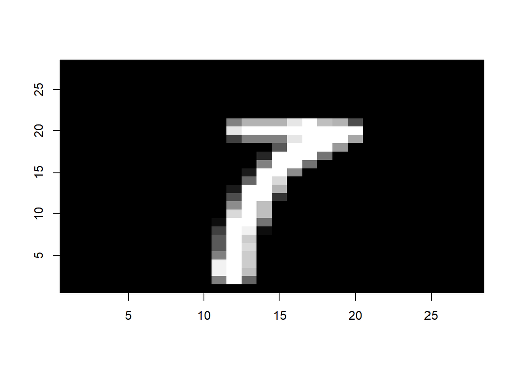

```r
print_image1(645)
```

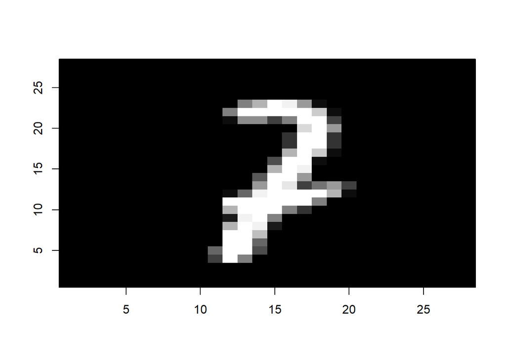

```r
print_image1(885)
```

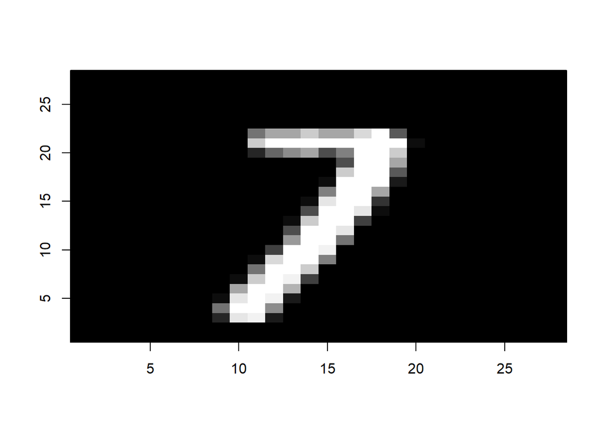

```r
print_image1(1847)
```

**A. randomForest() 함수를 사용하여 bagging model을 만들어보자. mtry를 제외한 옵션은 모두 default 값을 사용한다. plot() 함수를 사용하여 Bagging model에서 tree의 수의 증가에 따른 OOB classification error rate의 변화를 그래프로 출력해보자. 어떤 경향을 보이는가?**

- 처음 tree의 수가 많아질수록 예측오차가 줄어드는 경향이 있지만, 120개가량부터는 비슷한 예측오차를 보인다.

**B. Bagging model로 test set에 대한 예측을 수행하고, confusion matrix를 계산해보자. Test set에 대한 예측정확도는 얼마인가? 4번에서 계산한 prunned tree model에 비해서 성능이 얼마나 향상되었는가?**

- Accuracy : 0.8965 -> 89.65%
- 4번에서 계산한 prunned tree model에 비해 성능이 월등히 향상되었다.(41.25% -> 89.65%)

**C. randomForest() 함수의 default 옵션을 사용하여 random forest model을 만들어보자. 그리고 Bagging과 random forest 모델의 Tree의 수의 증가에 따른 OOB classification error rate의 변화를 하나의 그래프에 그려보고 두 모델의 성능을 비교해보자.**

- 두 모델의 성능은 비슷한 경향과 성능을 보이지만, Random Forest model이 더 적은 tree의 수부터 비슷한 예측오차를 보인다.

**D. Random forest model로 test set에 대한 예측을 수행하고, confusion matrix를 계산해보자. Test set에 대한 예측 정확도는 얼마인가? Bagging model에 비해서 성능이 얼마나 향상되었는가?**

- Accuracy : 0.9148 -> 91.48%
- Bagging model에 비해 성능이 소폭 향상되었다. (89.65% -> 91.48%)

**E. D번의 confusion matrix 결과로부터, 분류가 가장 정확한 숫자는 몇인가? 가장 분류가 어려운 숫자는 몇인가?**

**F. 실제 값은 7이지만 Random forest model에 의해 1로 예측되는 test data를 찾아 이미지를 몇 개 출력해보자. 눈으로 확인했을 때 7과 1의 구별이 어려운가?**

- 육안으로 확인했을때, 7과 1의 구분이 애매하다.